# Uso R Markdown para aula de Estatística da UNIRIO

Thiago de Araújo & Steven Dutt Ross

27 de outubro de 2017

# Visão Geral

R Markdown é uma maneira muito simples de escrever relatórios, além de rodar seu código em R automaticamente. Ele também permite que você use linguagem matemática, hiperlinks, imagens e outras formatações básicas. O objetivo deste documento é explicar, com exemplos, como usar seus recursos mais essenciais. (Para maiores informações, veja: http://rmarkdown.rstudio.com)

Este guia pressupõe que você conheça, ao menos, um pouco de R.

Este documento é baseado (uma tradução?) no tutorial do prof. Cosma Shalizi que está em http://www.stat.cmu.edu/~cshalizi/rmarkdown/.

Correções e sugestões são bem-vindas.

# Mark Up, Markdown

Provavelmente você está acostumado a usar programas de processamento de texto, como o *Microsoft Word*, que empregam o princípio do “o que você vê é o que você obtém” (WYSIWYG): você deseja que algumas palavras sejam impressas em itálico e, com um clique, logo estão em itálico lá na tela. Você quer que outras palavras tenham uma fonte maior e diferente, então você apenas seleciona a fonte e seu tamanho, e assim por diante. Isso funciona bem o suficiente para n00bs leigos, mas não é uma base viável para um sistema de formatação de texto, porque depende de um programa específico: (a) saber o que você quer dizer e (b) implementá-lo bem. Durante várias décadas, os sistemas realmente sérios de escrita basearam-se em um princípio muito diferente, o da marcação de texto. A idéia essencial em uma **linguagem de marcação** é que ela trabalha em texto comum, além de sinais que indicam como alterar a formatação ou o significado do texto. Algumas linguagens de marcação, como o HTML (*Hyper-Text Markup Language*), utilizam uma sintaxe muito técnica; outras, como o chamado **Markdown**, são mais sutis. Por exemplo, as frases anteriores no **Markdown** se parecem com isto:

```
Durante várias décadas, os sistemas realmente sérios de escrita basearam-se em um princípio muito diferente, o da marcação de texto. A idéia essencial em uma **linguagem de marcação** é que ela trabalha em texto comum, além de sinais que indicam como alterar a formatação ou o significado do texto. Algumas linguagens de marcação, como o HTML (*Hyper-Text Markup Language*), utilizam uma sintaxe muito técnica; outras, como o chamado **Markdown**, são mais sutis.
```

Cada linguagem de marcação é *renderizada* em um formato que inclui uma bela formatação, imagens, matemática, códigos, etc., etc., especificadas pela marcação. No caso do HTML, o programa de renderização é chamado de *“web browser”* (navegador *web*). A maioria dos computadores que interpretam o Markdown sabe como convertê-lo para HTML (visualizando o documento Markdown no navegador), PDF (visualizando o documento num leitor de PDF, como Acrobat ou outros), ou o Word (o que seria muito triste :( ).

As vantagens das linguagens de marcação são muitas: elas tendem a ser mais portáteis, menos custosas a empresas de software e mais estáveis ao longo do tempo do que os programas de processamento de texto WYSIWYG. R Markdown é gratuito **(você nunca pagará um dólar para usá-lo)** e livre (a documentação está completamente aberta a todos). Mesmo que você prefira o Word, a pura estabilidade das linguagens de marcação as torna superiores para documentos científicos.

[**Markdown**](http://daringfireball.net/projects/markdown/basics) é uma linguagem de marcação simples inventada por John Gruber. Hoje, existem muitos programas que traduzem documentos escritos em Markdown para documentos em formato HTML, PDF ou mesmo Word (entre outros).

[**R Markdown**](http://rmarkdown.rstudio.com), por sua vez, é uma extensão do Markdown para incorporar código em execução, em R, incluindo o resultado no documento. O presente guia mostra, por sua vez, três aspectos do R Markdown: como incluir formatação básica; como incluir o código R e sua saída; e como incluir código matemático.

# Renderizando e Editando

Para escrever em R Markdown, você precisará de um editor de texto: programa que permite ler e escrever arquivos de texto simples. Você também precisará do R e do pacote `rmarkdown` (bem como todos os pacotes que dependem dele).

- A maioria dos computadores vem com um editor de texto (TextEdit no Mac, Notepad em máquinas Windows, etc.).
- Há também muitos outros editores mais robustos.
- Você *pode* usar o Word (ou qualquer outro processador de texto WYSIWYG), tomando cuidado apenas de salvar o seu documento em formato de texto simples. Entretanto, eu não recomendo isso.
- [R Studio](http://www.rstudio.com) vem com um editor de textos próprio, apropriado, e com muitas ferramentas para se trabalhar com documentos R Markdown.

Se esta é sua primeira vez usando um editor de texto para algo sério, eu recomendo usar o **RStudio**.

### Renderizando no RStudio

Supondo que você tenha o documento R Markdown aberto no editor de texto, clique no botão “knit”.

### Renderizando no R sem usar o R Studio

Use o comando `render` no pacote `rmarkdown`.

# Formatação Básica em R Markdown

Na maior parte do documento, texto é apenas texto. Uma vantagem do R Markdown é que você digita seu documento como você normalmente faz.

### Quebra de Parágrafos e Quebra de Linhas

Para inserir uma quebra entre os paragráfos, inclua uma linha comum em branco.

Para forçar uma quebra de linha, ponha *dois* espaços em branco ao final da linha.

```
Para inserir uma quebra entre os paragráfos, inclua uma linha comum em branco.

Para forçar uma quebra de linha, ponha _dois_ espaços em branco ao final da linha.
```

### Cabeçalhos

O caractere `#` no início de uma linha significa que o resto da linha será interpretado como um cabeçalho de seção. O número de `#`s no começo da linha indica, respectivamente, o número da seção, sub-seção, sub-sub-seção, etc. do documento. Por exemplo, o `Formatação Básica em R Markdown` acima é precedido por um único `#` mas o `Cabeçalhos` do começo deste parágrafo foi precedido por `###`. Não separe cabeçalhos por quebra de linhas.

### Itálico, Negrito

Para deixar um texto em *itálico* ele deve ficar dentro de um *único conjunto de underscores* ou *asteriscos*. Para usar **negrito**, coloque o texto dentro de um **duplo conjunto de underscores** ou **asteriscos**.

```
Para deixar um texto em _itálico_ ele deve ficar dentro de um _único conjunto de underscores_ ou *asteriscos*. Para usar **negrito**, coloque o texto dentro de um __duplo conjunto de underscores__
ou **asteriscos**.
```

### Citações

Para citar um texto, o parágrafo deve ser iniciado por `>` (sinal maior que):

> In fact, all epistemological value of the theory of probability is based on this: that large-scale random phenomena in their collective action create strict, nonrandom regularity. [Gnedenko and Kolmogorov, *Limit Distributions for Sums of Independent Random Variables*, p. 1]

```
> In fact, all epistemological value of the theory of probability is based on this: that large-scale random phenomena in their collective action create strict, nonrandom regularity.  [Gnedenko and Kolmogorov, _Limit Distributions for Sums of Independent Random Variables_, p. 1]
```

### Fonte de console

Para imprimir um texto com fonte de largura fixa (estilo código-fonte), deve-se iniciá-lo e termina-lo com um sinal de crase, sem quebras de linha no texto. (Por exemplo, `R` vs. R.) Se você quiser exibir várias linhas como um próprio texto, insira três crases no começo e ao final do texto:

```
O texto a ser impresso em uma fonte de largura fixa, inicia e termina com
um sinal de crase, sem quebras de linha no texto. (Por exemplo, `R` vs. R.)
```

### Lista de Marcadoress

- Esta é uma lista de marcadores (lista não ordenada) onde os itens são marcos com pontos (*bullets*).
- Cada item da lista deve começar com um `*` (asterisco) ou um único hífen (`-`).
- Cada item deve estar em uma nova linha.
  - Para sub-bullets, idente as linhas (recue à direita) e as inicie com `+`.
  - Sub-sub-bullets não são realmente importantes em R Markdown.

### Listas Numeradas

1. As linhas que começam com um número (de 0–9), seguido de um texto, serão interpretadas como itens em uma lista enumerada.
2. O R Markdown lida com a numeração ao processar automaticamente.
3. Isso pode ser útil quando você perde a contagem ou não atualiza os números sozinho ao editar. (Consulte atentamente o arquivo .Rmd para este item.) a. Você pode criar sub-listas de listas enumeradas com letras para cada sub-item. b. No entanto, são uma coisa frágil, o que é melhor você não forçar demais.

### Título, Autor, Data, Formato de saída, Índice

Você pode especificar conteúdos como título, autor e data no **cabeçalho** do seu arquivo R Markdown (atributos em inglês). Isso vai no início do arquivo, precedido e seguido por três hífens. Assim, o início deste arquivo ficará como:

```
---
title: Usando R Markdown para anotações de aula
author: DATAUNIRIO
date: Primeira versão 7 janeiro de 2016, revisado em 22 agosto de 2016
---
```

Você também pode usar o cabeçalho para dizer ao R Markdown se deseja que ele seja processado para HTML (padrão), PDF ou outro formato. Para que ele seja transformado em PDF, por exemplo, eu escrevi:

```
---
title: Uso R Markdown para aula de Estatística da UNIRIO
author: DATAUNIRIO
date: Primeira versão 7 janeiro de 2016, revisado em 22 agosto de 2016
output: pdf_document
---
```

Você pode adicionar uma tabela de conteúdos como uma opção para o tipo de saída.

```
---
title: Uso R Markdown para aula de Estatística da UNIRIO
author: DATAUNIRIO
date: Primeira versão 7 janeiro de 2016, revisado em 22 agosto de 2016
output:
  html_document:
    toc: true
---
```

- Para criar PDFs, um programa chamado `LaTeX` (veja abaixo) deve ser instalado no seu computador.
- Outros formatos de saída podem estar disponíveis. Veja `help (render)` no pacote `rmarkdown`.
- Existem muitas, muitas outras opções de formatação que podem ser dadas no cabeçalho; consulte os principais arquivos de ajuda do R Markdown on-line.

# Hiperlinks e Imagens

### Hiperlinks

Os hiperlinks (links) são ancorados por URLs e fáceis de usar: basta digitar a URL, como, por exemplo, https://github.com/DATAUNIRIO/rmarkdown-anotacoes-classe/blob/master/manualTraduzido.Rmd para obter a fonte do arquivo deste documento.

Os hiperlinks ancorados no texto têm a [âncora entre colchetes e o link entre parênteses] (https://github.com/DATAUNIRIO/rmarkdown-anotacoes-classe/blob/master/manualTraduzido.Rmd).

```
Os hiperlinks ancorados no texto têm a [âncora entre colchetes e o link
entre parênteses] (https://github.com/DATAUNIRIO/rmarkdown-anotacoes-classe/blob/master/manualTraduzido.Rmd)
```

### Imagens

```
![Uma imagem de um reino remoto](https://raw.githubusercontent.com/DATAUNIRIO/SER2/master/dashboardGOT/imagem/GOT.png)
```

Não existe uma maneira de redimensionar imagens usando comandos próprios Markdown. No R Markdown, no entanto, você pode usar o seguinte hack:

````
```{r, fig.retina=NULL, out.width=100, echo=FALSE}
knitr::include_graphics("https://raw.githubusercontent.com/DATAUNIRIO/SER2/master/dashboardGOT/imagem/GOT.png")
```
````

Esse código chama um comando R incluído no pacote `knitr`, com algumas opções sobre como o R é executado (descrito abaixo).

# Incluindo Código

O legal do R Markdown é que ele também permite que você inclua seu código e o executa automaticamente quando seu documento é processado e, de forma incomparável, inclui os resultados desse código em seu documento. O código vem em duas variedades: **chunks** (pedaços) de código ou código **inline**.

### Pedaços de código e seus resultados

Um **pedaço** de código é simplesmente um trecho de código isolado. Ele é precedido por `` ``` {r} `` em uma linha e termina por uma linha que apenas diz `` ``` ``. O código entra no meio. Aqui, por exemplo, é algum código que carrega um conjunto de dados de uma biblioteca e faz um gráfico de dispersão.

````
```{r}
library(MASS)
data(cats)
plot(Hwt ~ Bwt, data=cats, xlab="Body weight (kg)", ylab="Heart weight (g)")
```
````

```r
library(MASS)
```

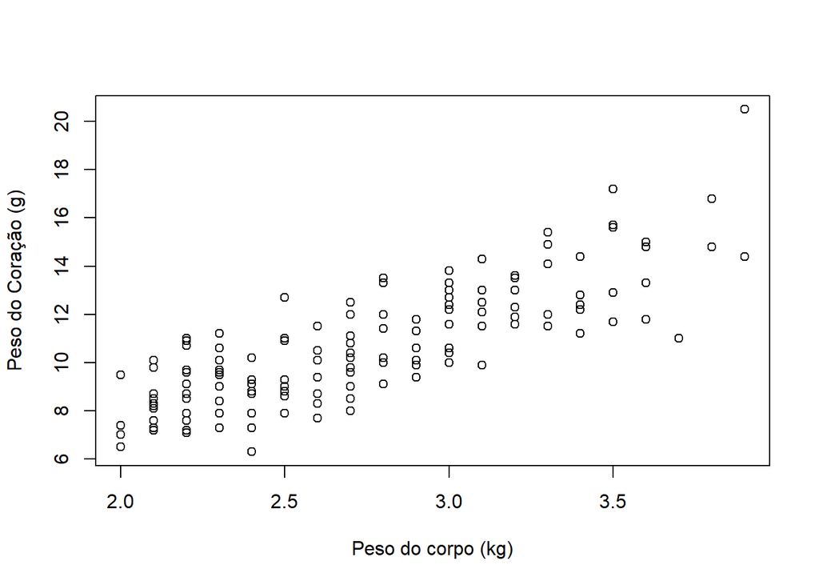

```r
data(cats)
plot(Hwt ~ Bwt, data=cats, xlab="Peso do corpo (kg)", ylab="Peso do Coração (g)")
```

Primeiro, observe como o código está incluído, bem formatado, no documento. Em segundo lugar, observe como a saída do código também é automaticamente incluída no documento. Se o seu código produzir números ou texto, eles também podem ser incluídos:

```r
with(cats, cor(Hwt, Bwt))
```

```
## [1] 0.8041274
```

### Visto, mas não ouvido

Os pedaços de código (exceto código inline) podem ter um monte de **opções** que modificam a forma como eles são executados e como eles aparecem no documento. Estas opções vão depois o `r` inicial e antes do fechamento `}` que representa o início de um pedaço código. Uma das opções mais comuns desativa a impressão do código, porém, deixa os resultados isolados: `` ```{r, echo=FALSE} ``

Outra opção executa o código, mas não inclui nem o texto do código nem a saída. `` ```{r, include=FALSE} `` Isso pode parecer bobo, mas pode ser útil para pedaços de código que *configuram como carregar arquivos de dados*, ou estimativas do modelo inicial, etc.

Outra opção imprime o código no documento mas não o executa: `` ```{r, eval=FALSE} `` Isso também é útil se você quiser comentar sobre o código (de modo que ele fique bem formatado).

### Nomeando pedaços de código

Você pode atribuir nomes aos pedaços de código logo após a abertura, como `` ``` {r, nomeinteligente} ``. Esse nome é usado para as imagens (ou outros arquivos) que são gerados quando o documento é processado.

### Alterando tamanhos de imagem e alinhamentos

Há muitas opções para ajustar a colocação das figuras que o R produz. `fig.align` controla o **alinhamento** horizontal (esquerda, direita, ou centro).

Ao produzir PDF, as opções `out.height` e`out.width` permitem que você especifique a altura ou largura desejada da figura em polegadas, centímetros ou múltiplos de comprimentos pré-definidos (do `LaTeX`). Então, por exemplo, `` ``` r, out.height = "3in"} `` força a imagem a 3 polegadas de altura, enquanto que `` ```r, out.width = "0.48 \\ textwidth"} `` força a largura da imagem a ser um pouco menos do que metade da largura total do texto na página (de modo que duas dessas imagens se encaixam lado a lado). As próximas figuras ilustram isso.

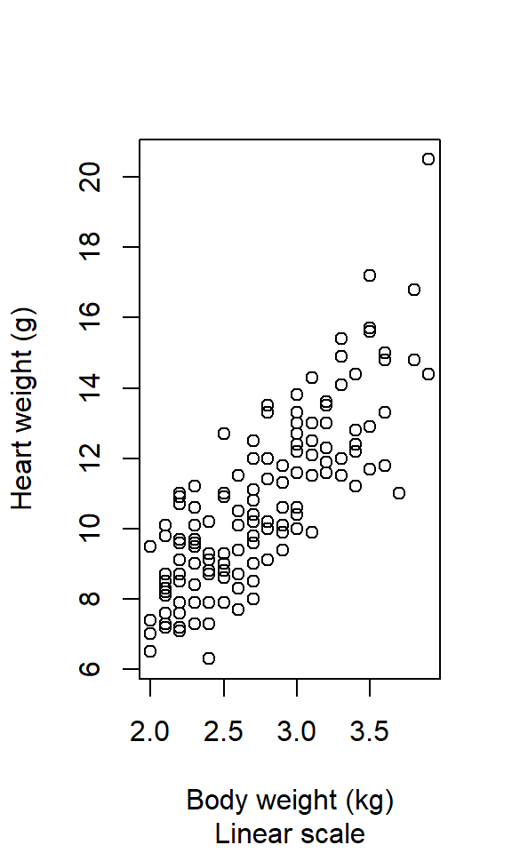

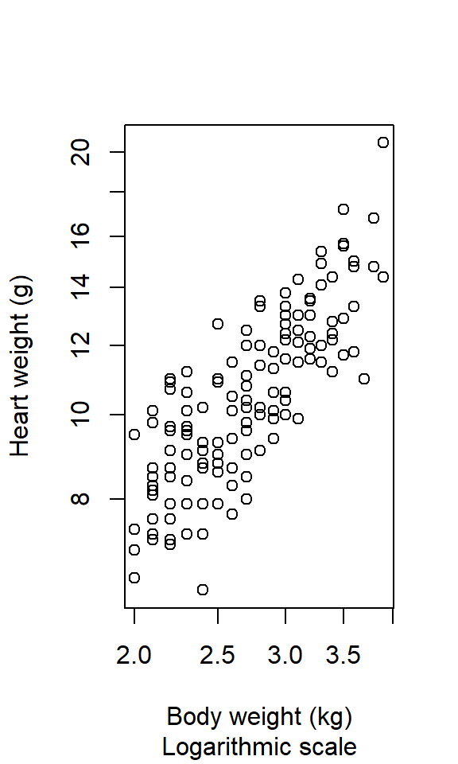

### Tabelas

A impressão padrão de matrizes, tabelas, etc., do R Markdown é, francamente, feia. O pacote `knitr` contém um comando muito básico, `kable`, que irá formatar uma matriz ou quadro de dados mais legalmente para exibição.

Compare:

```r
coefficients(summary(lm(Hwt ~ Bwt, data=cats)))
```

```
##               Estimate Std. Error    t value     Pr(>|t|)
## (Intercept) -0.3566624  0.6922770 -0.5152019 6.072131e-01
## Bwt          4.0340627  0.2502615 16.1193908 6.969045e-34
```

com

```r
library(knitr) # Only need this the first time!
kable(coefficients(summary(lm(Hwt ~ Bwt, data=cats))))
```

|  | Estimate | Std. Error | t value | Pr(>\|t\|) |
| --- | --- | --- | --- | --- |
| (Intercept) | -0.3566624 | 0.6922770 | -0.5152019 | 0.6072131 |
| Bwt | 4.0340627 | 0.2502615 | 16.1193908 | 0.0000000 |

— Pois é, os padrões do R imprimem um número louco de casas decimais, mas este não é o momento de discutir dígitos significativos, ou a função `signif`.

### “Caching” de pedaços de código (re-executando somente com modificações)

Por padrão, o R Markdown executará de novo seu código toda vez que você renderizar o seu documento. Se algum código do seu código for lento, isso pode aumentar ainda mais o tempo de renderização.

Você pode, no entanto, pedir ao R Markdown para monitorar se um pedaço de código foi modificado e apenas re-executar este pedaço. Isso é chamado **caching** do pedaço de código.

```r
lm(Hwt ~ Bwt, data=cats)
```

```
##
## Call:
## lm(formula = Hwt ~ Bwt, data = cats)
##
## Coefficients:
## (Intercept)          Bwt
##     -0.3567       4.0341
```

A questão é que um pedaço de código que não se alterou pode invocar resultados de pedaços anteriores, trechos modificados, e então nós _precisarIIIamos re-executar os pedaços desatualizados. Existem opções para informar manualmente o R Markdown que “este trecho depende desse fragmento anterior”, mas geralmente é mais fácil deixar ele mesmo cuidar disso, definindo a opção `autodep = TRUE`.

1. Se você carregar um pacote com os comandos `library()` ou `require()`, o R Markdown não é inteligente o suficiente para verificar se o pacote mudou (ou realmente foi instalado, se você sem ele instalado). Então isso não vai lançar uma re-execução automática de um pedaço de código em cache.
2. Para forçar manualmente a re-execução de todos os pedaços de código, o mais fácil de fazer é excluir o diretório que o R Markdown cria (algo como *filename*`_cache`) para armazenar o estado de todos os pedaços de código.

### Configuração de padrões para todos os pedaços de código

Você pode dizer para o R definir alguns padrões para se aplicar a todos os pedaços onde você não faz especificamente sobrecarregá-los. Aqui estão os que eu geralmente uso:

```r
# Precisamos do pacote knitr para definir opções de trechos de código
library(knitr)

# Seta opções do knitr para gerar código no relatório
# - Não imprime código
# - Salva os resultados para que os blocos de código não sejam executados novamente, a menos que o código mude (cache),
# _ou_ um bloco de código anterior relevante seja modificado (autodep), mas não o re-executa se o
# única coisa que mudou forem comentários (cache.comments)
# - Não obstrua a saída R com mensagens ou avisos (mensagem, aviso)
# Isto _deixará_ mensagens de erro aparecendo no relatório gerado
opts_chunk$set(echo=FALSE,
               cache=TRUE, autodep=TRUE, cache.comments=FALSE,
               message=FALSE, warning=FALSE)
```

Assim definimos algumas opções adicionais além das que eu discuti, como não re-executar um pedaço se apenas os comentários mudaram (`cache.comments = FALSE`), e deixando de receber mensagens e avisos. (Eu só recomendaria suprimir avisos se você tem a certeza de que seu código está ok.) Eu, normalmente, também atribuiria a este ponto de configuração a opção `include = FALSE`.

Você pode sobrescrever estes padrões definindo opções para trechos específicos.

### Mais Opções

Veja em [http://yihui.name/knitr/options/] para obter uma listagem completa das opções possíveis.

# Matemática no R Markdown

Como esta é uma aula de Estatística, é importante que você seja capaz de escrever expressões matemáticas, muitas vezes longas séries delas. O R Markdown oferece a sintaxe para tornar fórmulas e derivações matemáticas complexas, e exibi-las *muito* lindamente. Assim como o código,a fórmula matemática pode ser *inline* ou como (**apresentações**).

O código da fórmula matemática *inline* é marcado com um par de cifrão (`$`), as $\pi r^2$ or $e^{i\pi}$.

```
O código de matemática inline é marcado com um par de cifrão
(`$`), as $\pi r^2$ or $e^{i\pi}$.
```

Equações matemáticas são marcadas com `\[` and `\]`, como em
$$e^{i \pi} = -1$$

```
Equações matemáticas são marcadas com `\[` and `\]`, como em
\[
e^{i \pi} = -1
\]
```

Uma vez que seu texto está no modo matemático, o R Markdown faz o trabalho de converter seu texto matemático para um programa diferente, chamado LaTeX[^latex]. Ele é o sistema mais comum para a composição de documentos matemáticos em todas as ciências, e tem sido há décadas. Ele é extremamente poderoso, estável, disponível basicamente em todos as plataformas e completamente gratuito. Mas isso também o torná-lo, em seu poder total, muito complicado. Felizmente, para nossos propósitos, é bastante simples.

### Elementos do Modo Matemático

- A maioria das letras será renderizada em itálico (compare: a vs. `a` vs. $a$; apenas o último está em modo matemático). O espaçamento entre as letras também segue as convenções da matemática, então não a trate como só outra maneira de obter itálico. (Compare *speed*, em itálico simples, com $speed$, no modo matemático.)
- Letras gregas podem ser acessadas com a barra na frente de seus nomes, como `\alpha` para $\alpha$. Fazer a primeira letra em maiúscula te dá a letra maiúscula, como em `\Gamma` para $\Gamma$ vs. `\gamma` para $\gamma$. (As maiúsculas alpha e beta são as mesmas que as Romanas A e B, portanto, não precisa de comando especial para elas.)
- Existem outros comandos “cortados” (ou “escapados”) para outros símbolos matemáticos:
  - `\times` para $\times$
  - `\cdot` para $\cdot$
  - `\leq` e `\geq` para $\leq$ and $\geq$
  - `\subset` e `\subseteq` para $\subset$ and $\subseteq$
  - `\leftarrow`, `\rightarrow`, `\Leftarrow`, `\Rightarrow` para $\leftarrow$, $\rightarrow$, $\Leftarrow$, $\Rightarrow$
  - `\approx`, `\sim`, `\equiv` for $\approx$, $\sim$, $\equiv$
  - Veja, também, http://web.ift.uib.no/Teori/KURS/WRK/TeX/symALL.html para uma lista completa dos símbolos. (http://tug.ctan.org/info/symbols/comprehensive/symbols-a4.pdf lista de *todos* os símbolos disponíveis no `LaTeX`, incluindo muitos caracteres especiais não-matemáticos)
- Subscritos vêm depois de um caractere underscore, `_`, e sobrescritos vêm depois de um circunflexo, `^`, como `\beta_1` para $\beta_1$ ou `a^2` para $a^2$.
- As chaves são usadas para criar agrupamentos que devem ser mantidos em conjunto, como, por exemplo, `a_{ij}` para $a_{ij}$ (vs. `a_ij` para $a_ij$).
- Se você precisa de algo em fonte normal (romana) no modo matemático, use `\mathrm`, como `t_{\mathrm{in}}^2` para $t_{\mathrm{in}}^2$.
- Para texto negrito, use `\mathbf`, como

  ```
  (\mathbf{x}^T\mathbf{x})^{-1}\mathbf{x}^T\mathbf{y}
  ```

  para
  $$(\mathbf{x}^T\mathbf{x})^{-1}\mathbf{x}^T\mathbf{y}$$
- Acentos nos caracteres funcionam como mudanças de fonte: `\vec{a}` gera $\vec{a}$, `\hat{a}` gera $\hat{a}$. Alguns acentos, particularmente os “chapéus”, funcionam melhor com espaços, como `\widehat{\mathrm{Var}}` produzindo $\widehat{\mathrm{Var}}$.
- Nomes de funções são, geralmente, escritos em fonte normal e espaçados de forma diferente: $\log{x}$, não $log x$. O `LaTeX` e, por consequência, o `R Markdown` também, conhece muitas dessas funções e seus nomes iniciam com `\`. Por exemplo: `\log`, `\sin`, `\cos`, `\exp`, `\min`, etc. Siga estes nomes de funções com o argumento em chaves; isso ajuda o `LaTeX` a descobrir o que exatamente o argumento é, e mantê-lo agrupado com o nome da função quando está colocando o texto. Então `\log{(x+1)}` é melhor que `\log (x+1)`.
- Frações podem ser criadas com `\frac`, como:

  ```
  \frac{a+b}{b} = 1 + \frac{a}{b}
  ```

  produz
  $$\frac{a+b}{b} = 1 + \frac{a}{b}$$
- Somas podem ser escritas como:

  ```
  \sum_{i=1}^{n}{x_i^2}
  ```

  produzirá
  $$\sum_{i=1}^{n}{x_i^2}$$
  Os limites inferior e superior do somatório após a `\sum` são ambos opcionais. Produtos e integrais funcionam de forma semelhante, apenas com `\prod` e `\int`:
  $$n! = \prod_{i=1}^{n}{i}$$
  $$\log{b} - \log{a} = \int_{x=a}^{x=b}{\frac{1}{x} dx}$$
  `\sum`, `\prod` and `\int` se ajustam automaticamente ao tamanho da expressão a qual são somados, multiplicados ou integrados.
- “Delimitadores”, como parênteses ou chaves, podem se redimensionar automaticamente para corresponder ao que eles têm ao redor. Para fazer isso, você precisa usar `\left` e `\right`,como

  ```
  \left( \sum_{i=1}^{n}{i} \right)^2 = \left( \frac{n(n-1)}{2}\right)^2 = \frac{n^2(n-1)^2}{4}
  ```

  será renderizado como
  $$\left( \sum_{i=1}^{n}{i} \right)^2 = \left( \frac{n(n-1)}{2}\right)^2 = \frac{n^2(n-1)^2}{4}$$
- Para usar chaves como delimitadores, anteceda-os com barras como `\{` e `\}` para $\{$ e $\}$.
- Múltiplas equações, com seus sinais iguais alinhados, podem ser criadas usando `eqnarray`, da seguinte forma:

  ```
  \[
  \begin{eqnarray}
  X & \sim & \mathrm{N}(0,1)\\
  Y & \sim & \chi^2_{n-p}\\
  R & \equiv & X/Y \sim t_{n-p}
  \end{eqnarray}
  \]
  ```

$$\begin{eqnarray}
X & \sim & \mathrm{N}(0,1)\\
Y & \sim & \chi^2_{n-p}\\
R & \equiv & X/Y \sim t_{n-p}
\end{eqnarray}$$
Observe que `&` envolve o que se passa no meio em cada linha e cada linha (exceto a última) é encerrada com `\\`. O lado esquerdo ou direito da equação pode estar em branco que o espaço será feito:

```
\[
\begin{eqnarray}
P(|X-\mu| > k) & = & P(|X-\mu|^2 > k^2)\\
& \leq & \frac{\mathbb{E}\left[|X-\mu|^2\right]}{k^2}\\
& \leq & \frac{\mathrm{Var}[X]}{k^2}
\end{eqnarray}
\]
```

$$\begin{eqnarray}
P(|X-\mu| > k) & = & P(|X-\mu|^2 > k^2)\\
& \leq & \frac{\mathbb{E}\left[|X-\mu|^2\right]}{k^2}\\
& \leq & \frac{\mathrm{Var}[X]}{k^2}
\end{eqnarray}$$

(Resumindamente `LaTeX`, `\begin{eqnarray}` entra automaticamente no modo matemático, mas o R Markdown precisa de um empurrãozinho.)

### Traduzindo Matemática para `LaTeX`

O `LaTeX` é projetado para que cada parte de uma expressão matemática tenha uma relação razoavelmente <– direta ao que você escreve. Ainda assim, ele pode ser um um pouco intimidador no início. O que muitas pessoas acham útil é começar com alguma página com código matemático impresso ou manuscrito e depois traduzi-la, linha por linha, no `LaTeX`, processando para ver se ele saiu direito (e, caso contrário, entender onde consertar coisas). Se você precisa fazer expressões matemáticas para um trabalho, pode ser uma boa ideia escrever as contas à mão e depois aproveitá-lo no `LaTeX`, se a aula o exige (como este), ou não. Eventualmente, com a prática, a tradução se tornará fluida e automática. Algumas pessoas inovam ainda a matemática escrevendo no `LaTeX`.

### `LaTeX` não verifica a correção

`LaTeX` não verifica se sua matemática está *certa*; ele apenas verifica se descobre o que você está tentando dizer bem o suficiente para digitar e configurá-lo. Assim, por exemplo, não tem nenhum problema com o seguinte:

$$\begin{eqnarray}
(n+1)(n-1) & = & n^2\\
n^2 -1 & = & n^2\\
-1 & = & 0\\
1 & = & 0\\
-1 & = & 1
\end{eqnarray}$$

(Existem programas de computador para matemática simbólica que, de fato, verifique se sua operação matemática está correta, pelo menos se você estiver trabalhando na sub-área de matemática a qual eles são projetados para lidar. Até onde eu sei, ninguém realmente os combinou com `LaTeX`.)

# Para avançar em R Markdown…

Para maiores informações sobre o R Markdown, o melhor site é http://rmarkdown.rstudio.com

Para maiores informações sobre o `LaTeX`, sugerimos o livro do Leslie Lamport, *LaTeX: A Document Preparation System* (2nd ed., Reading, Mass.: Addison-Wesley, 1994).

[*LaTeX*](https://en.wikibooks.org/wiki/LaTeX), do Wikibooks é bastante acessível.

R Markdown é baseado no pacote `knitr` desenvolvido pelo Yihui Xie. Para integrar o R com o `LaTeX`; veja o site http://yihui.name/knitr/, a documentação está no livro do Yihui Xie *Dynamic Documents with R and knitr* (2nd edition, Boca Raton, Florida; CRC Press, 2016).

Um texto com a explicação de como o Word não é muito eficiente como processador de texto pode ser encontrado aqui. “The word processor is a stupid and grossly inefficient tool for preparing text for communication with others” http://ricardo.ecn.wfu.edu/~cottrell/wp.html.

#### Biografia dos autores:

**Steven Dutt-Ross**  
[Steven Dutt-Ross](https://stevendutt.shinyapps.io/pagina/) é um entusiasta do R, professor e pesquisador do Departamento de Métodos Quantitativos da UNIRIO - DMQ/UNIRIO  
**Thiago de Araujo Severo dos Santos**  
[Thiago de Araujo Severo dos Santos](https://github.com/thiagoassantos/) é estudante de Sistemas de Informação da UNIRIO e bolsista do projeto de extensão [DATAUNIRIO](https://dataunirio.github.io/).